# Challenger Notebook

The dataset consists of 144 observations of 5 variables consisting of:  
Flight: name of flight; Date (date of flight);  
Field (1 if an Oring fails and 0 otherwise);  
Temp (Temperature in degrees Fahrenheit);  
Pres (Leak check pressure in psi).  
Each flight had 6 orings.

```r
summary(orings)
```

```
    Flight              Date               Field              Temp            Pres
 Length:144         Length:144         Min.   :0.00000   Min.   :31.00   Min.   : 50.0
 Class :character   Class :character   1st Qu.:0.00000   1st Qu.:66.75   1st Qu.: 87.5
 Mode  :character   Mode  :character   Median :0.00000   Median :70.00   Median :200.0
                                       Mean   :0.07246   Mean   :67.96   Mean   :154.2
                                       3rd Qu.:0.00000   3rd Qu.:75.00   3rd Qu.:200.0
                                       Max.   :1.00000   Max.   :81.00   Max.   :200.0
                                       NA's   :6
```

Let us check the number of orings that have failed out of 6 in each of the flights launched.

```r
table(tapply(orings$Field, orings$Flight, sum))
```

```
 0  1  2  3
16  5  1  1
```

We plot the failures and temperatures.  
We use jitter plot to randomly perturb points by a small amount to see the points that lie on top of each other better.

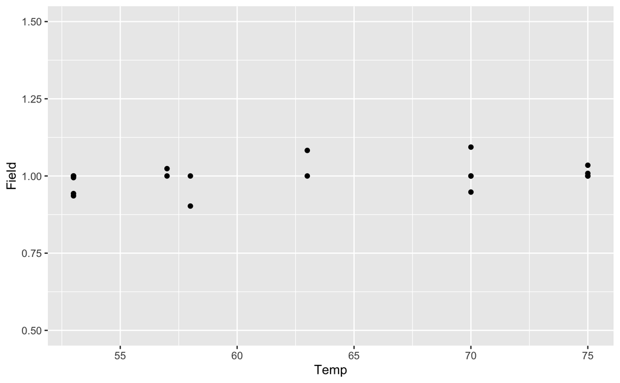

Fitting a linear regression model

```r
summary(model1)
```

```
Call:
lm(formula = Field ~ Temp + Pres, data = orings)

Residuals:
     Min       1Q   Median       3Q      Max
-0.27680 -0.09548 -0.03457 -0.00874  0.99126

Coefficients:
              Estimate Std. Error t value Pr(>|t|)
(Intercept)  0.7264305  0.2181384   3.330  0.00112 **
Temp        -0.0106657  0.0030704  -3.474  0.00069 ***
Pres         0.0005783  0.0003176   1.821  0.07088 .
---
Signif. codes:  0 ‘***’ 0.001 ‘**’ 0.01 ‘*’ 0.05 ‘.’ 0.1 ‘ ’ 1

Residual standard error: 0.2487 on 135 degrees of freedom
  (6 observations deleted due to missingness)
Multiple R-squared:  0.09941,   Adjusted R-squared:  0.08607
F-statistic: 7.451 on 2 and 135 DF,  p-value: 0.0008524
```

Now we use only Temperature

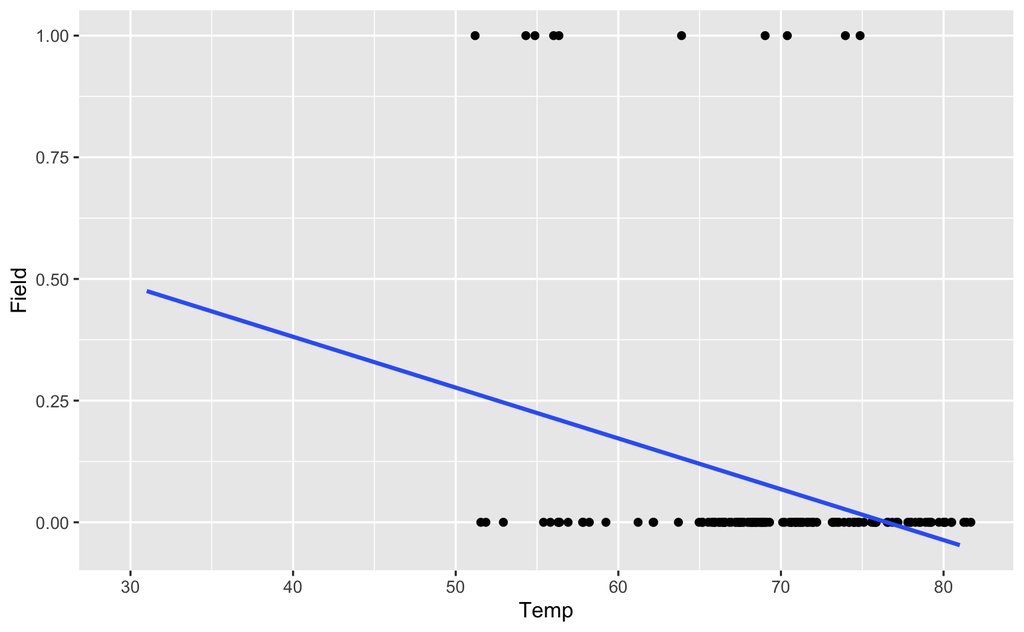

The result indicates that the linear fit is not particularly convincing with a small value of R-squared, though it does identify that temperature has a significant effect and it is a negative impact.

Fitting a logistic regression model: glm() is a generalized linear model that can be used to fit a logistic regression model by choosing family=binomial.

```r
summary(model3)
```

```
Call:
glm(formula = Field ~ Temp + Pres, family = "binomial", data = orings)

Deviance Residuals:
    Min       1Q   Median       3Q      Max
-0.9243  -0.3680  -0.2432  -0.2059   2.8217

Coefficients:
             Estimate Std. Error z value Pr(>|z|)
(Intercept)  3.958071   3.497847   1.132  0.25781
Temp        -0.119355   0.044945  -2.656  0.00792 **
Pres         0.008692   0.007689   1.130  0.25829
---
Signif. codes:  0 ‘***’ 0.001 ‘**’ 0.01 ‘*’ 0.05 ‘.’ 0.1 ‘ ’ 1

(Dispersion parameter for binomial family taken to be 1)

    Null deviance: 71.751  on 137  degrees of freedom
Residual deviance: 60.470  on 135  degrees of freedom
  (6 observations deleted due to missingness)
AIC: 66.47

Number of Fisher Scoring iterations: 6
```

Now we use only temperature

```r
summary(model4)
```

```
Call:
glm(formula = Field ~ Temp, family = binomial, data = orings)

Deviance Residuals:
    Min       1Q   Median       3Q      Max
-0.9155  -0.3770  -0.3075  -0.2036   2.7387

Coefficients:
            Estimate Std. Error z value Pr(>|z|)
(Intercept)  6.75183    2.97991   2.266  0.02346 *
Temp        -0.13971    0.04647  -3.007  0.00264 **
---
Signif. codes:  0 ‘***’ 0.001 ‘**’ 0.01 ‘*’ 0.05 ‘.’ 0.1 ‘ ’ 1

(Dispersion parameter for binomial family taken to be 1)

    Null deviance: 71.751  on 137  degrees of freedom
Residual deviance: 62.083  on 136  degrees of freedom
  (6 observations deleted due to missingness)
AIC: 66.083

Number of Fisher Scoring iterations: 6
```

```r
model3$aic
```

```
[1] 66.4705
```

Model 3 describes  
$Prob(Fail = 1) = exp(3.95-0.119 Temp + 0.008 Pres)/(1+exp(3.95-0.119Temp+0.008Pres)).$  
The result indicates that Temp is significant at the 5% level.

```r
model4$aic
```

```
[1] 66.08252
```

Model 4 has a fit given by  
$P(Fail=1) = exp(6.75-0.1397Temp)/(1+exp(6.75-0.1397Temp))$.  
In terms of AIC, Model 4 is preferred to Model 3. We drop the pressure variable in this example.

Predictions:

```r
predict(model4, newdata=orings[144,]) # predicts on log(odds) scale
predict(model4,newdata=orings[144,], type="response")
```

[output not shown]

Plots

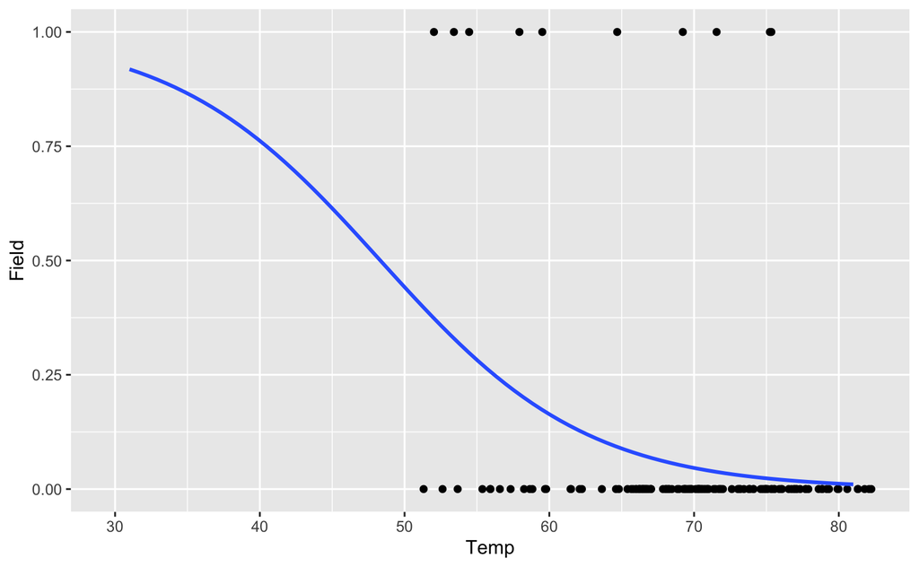

Developing a predictive rule (classifier) and tabulating confusion matrices.  
Here we are still evaluating this with the training data. Typically we will use a test data to check on the results.

```r
table(Pred[1:138]>0.2,orings$Field[1:138])
```

```
          0   1
  FALSE 115   5
  TRUE   13   5
```

The ROCR package is useful for visualizing the performance of classifier. The prediction function transforms the data to a standardized format and the performance function is used to do all kinds of prediction evaluations.

```r
performance(ROCRpred,measure="auc")@y.values
```

```
[[1]]
[1] 0.725
```